# Control de Calidad

2026-06-22_00-08-27

## Resumen General

Se analizaron **65** muestra(s) biológica(s) (**130** archivos FASTQ, R1 + R2).

Estadísticas generales por archivo

| Archivo | Hebra | Reads Totales | Calidad Media | Longitud Media | GC (%) |
| --- | --- | --- | --- | --- | --- |
| Healthy25_26_L001_R2_001 | R2 | 38,879 | 28.0 | 251 | 53.1 |
| MS20_6_L001_R2_001 | R2 | 100,000 | 28.4 | 251 | 50.5 |
| Healthy30_19_L001_R2_001 | R2 | 64,564 | 28.5 | 251 | 53.6 |
| Healthy23_14_L001_R2_001 | R2 | 93,131 | 28.6 | 251 | 53.8 |
| Healthy33_10_L001_R2_001 | R2 | 60,948 | 28.6 | 251 | 52.7 |
| MS13_7_L001_R2_001 | R2 | 100,000 | 28.8 | 251 | 53.3 |
| Healthy22_15_L001_R2_001 | R2 | 93,090 | 28.8 | 251 | 52.2 |
| Healthy31_20_L001_R2_001 | R2 | 78,686 | 28.9 | 251 | 54.1 |
| MS12_25_L001_R2_001 | R2 | 68,687 | 29.0 | 251 | 54.2 |
| Healthy16_9_L001_R2_001 | R2 | 67,569 | 29.0 | 251 | 52.9 |
| MS10_11_L001_R2_001 | R2 | 100,000 | 29.0 | 251 | 52.1 |
| MS11_13_L001_R2_001 | R2 | 75,004 | 29.1 | 251 | 53.5 |
| MS18_16_L001_R2_001 | R2 | 74,442 | 29.2 | 251 | 51.5 |
| Healthy29_17_L001_R2_001 | R2 | 68,756 | 29.2 | 251 | 53.0 |
| MS15_23_L001_R2_001 | R2 | 77,758 | 29.3 | 251 | 52.9 |
| Healthy32_27_L001_R2_001 | R2 | 96,194 | 29.3 | 251 | 51.8 |
| MS17_30_L001_R2_001 | R2 | 70,472 | 29.3 | 251 | 51.8 |
| Healthy17_12_L001_R2_001 | R2 | 81,419 | 29.3 | 251 | 52.4 |
| Healthy18_8_L001_R2_001 | R2 | 100,000 | 29.4 | 251 | 54.2 |
| MS21_18_L001_R2_001 | R2 | 88,401 | 29.4 | 251 | 51.3 |
| Healthy21_22_L001_R2_001 | R2 | 100,000 | 29.4 | 251 | 51.8 |
| Healthy20_1_L001_R2_001 | R2 | 100,000 | 29.5 | 251 | 51.5 |
| MS19_5_L001_R2_001 | R2 | 70,903 | 29.5 | 251 | 51.1 |
| MS14_28_L001_R2_001 | R2 | 100,000 | 29.6 | 251 | 52.2 |
| Healthy24_24_L001_R2_001 | R2 | 52,195 | 29.8 | 251 | 51.6 |
| Healthy26_4_L001_R2_001 | R2 | 87,461 | 29.9 | 251 | 52.8 |
| Healthy28_3_L001_R2_001 | R2 | 63,983 | 29.9 | 251 | 52.0 |
| Healthy19_2_L001_R2_001 | R2 | 100,000 | 30.0 | 251 | 52.5 |
| Healthy27_29_L001_R2_001 | R2 | 78,470 | 30.1 | 251 | 51.1 |
| Healthy35_7_L001_R2_001 | R2 | 31,209 | 30.3 | 251 | 52.0 |

[output cut: 100 more lines]

## 1. Calidad por Posición y Hebra (distribución)

Por hebra (R1/R2) se muestran, por muestra, la **mediana** (azul), el **cuartil inferior Q25** (naranja) y el **percemtil P10** (morado) en cada posición. El truncado debe guiarse por el **cuartil inferior**: conviene truncar antes de que el Q25 cruce **Q20** (rojo). El percentil 10 muestra la cola baja de la distribución: una caída temprana respecto al Q25 indica heterogeneidad creciente entre lecturas en esa posición.

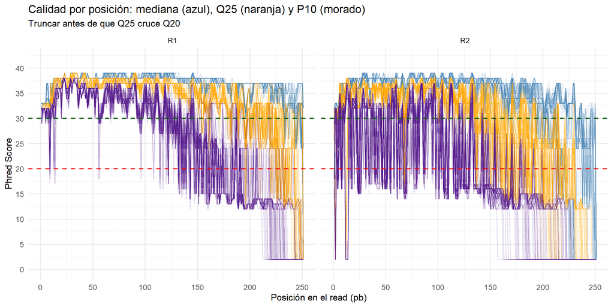

## 2. Error Esperado Acumulado (EE)

Por hebra (R1/R2) se muestra, por muestra, el **error esperado acumulado** (suma de la probabilidad de error en cada posición desde el inicio de la lectura), resumido en su **mediana** (azul), **cuartil superior Q75** (naranja) y **percentil 90** (morado) entre lecturas. A diferencia de la calidad, aquí el problema está en la **cola alta**: cuanto mayor el EE acumulado, más lecturas se descartarán al aplicar `maxEE` en `filterAndTrim()`.

La línea roja marca el `maxEE` de referencia (2). **Es un indicador, no una regla automática de truncado**: el punto donde la curva cruza esta línea debe contrastarse con la longitud esperada del amplicón y el solape necesario para `mergePairs()`, no usarse de forma aislada.

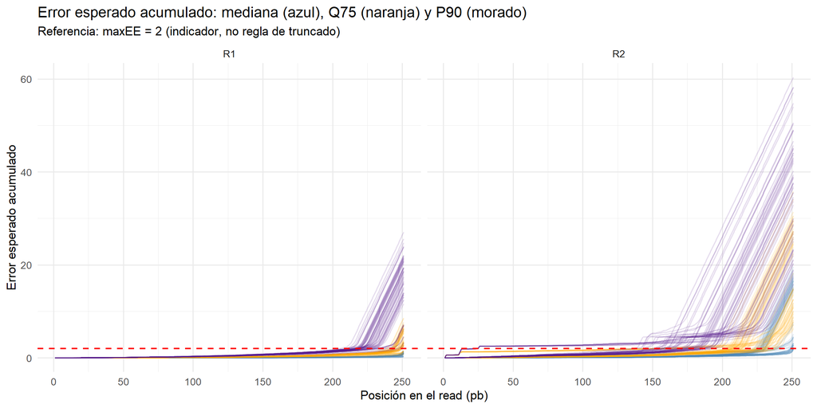

## 3. Archivos con Calidad Baja

**Excelente:** Todas los archivos tienen calidad media ≥ Q 20

## 4. Distribución de Calidad Media

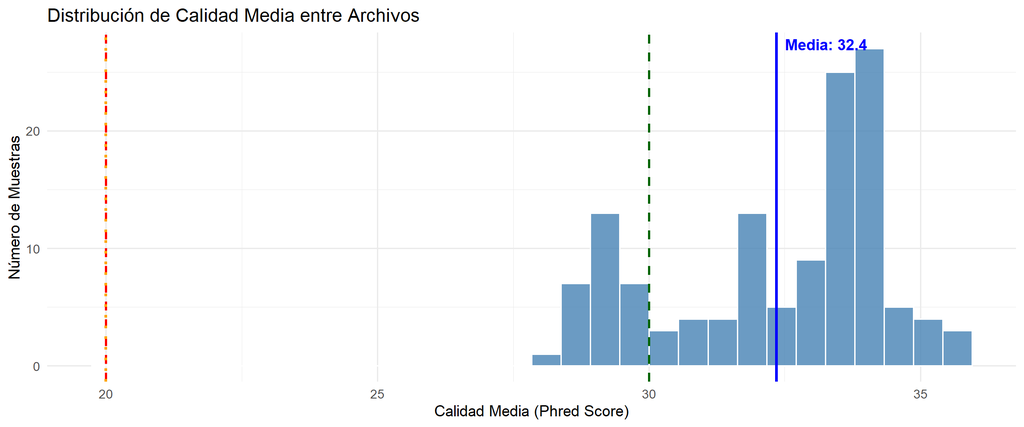

## 5. Contenido GC

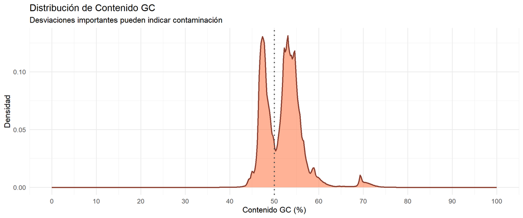

## 6. Conclusiones y Recomendaciones

#### Resumen Final:

- **Total de reads analizados:** 8,810,446
- **Calidad media global:** 32.4
- **Archivos con calidad baja:** 0 de 130 (0%)

*Informe generado el 2026-06-22_00-08-27- Umbral de calidad: Q20*